# COP CoV serological endpoint review

David Eyre, Tim Peto 14 December 2022

```r
library(tidyverse)
library(readxl)
library(lubridate)
theme_set(theme_light())
```

# Import data

## Read data

Read in data provided

```r
df_raw = read_excel("Data/Endpoint_review_06_12_2022_latest.xlsx")
```

## Reformat and truncate

Reformat to only keep required columns, and truncate all serology values to 10 if lower than 10

```r
df_pre = df_raw %>%
  select(subjectno, site, d0_1in50 = "D0 1/50 Serum Ab titre",
         d90_1in50 = "D90 1/50 Serum Ab titre",
         d0_1in400 = "D0 1/400 Serum Ab titre", d90_1in400 = "D90 1/400 Serum Ab titre",
         vac_1in50 = "Day vaccine 1/50 Serum Ab titre",
         vac_1in400 = "Day vaccine 1/400 Serum Ab titre",
         d0_dbs = "D0 DBS 1/66",
         d30_dbs = "D30 DBS 1/66",
         d60_dbs = "D60 DBS 1/66",
         d90_dbs = "D90 DBS 1/66",
         vac_dbs = "DVaccine DBS 1/66",
         pcr_result = "PCR_Res",
         pcr_date = "Swab date",
         randomisation_date = "Randomisation date",
         model = Model,
         flag = Flag
         ) %>%
  mutate(pcr_date = as.Date(pcr_date, "%d%b%Y"),
          d0_1in50 = ifelse(d0_1in50<10, 10, d0_1in50),
          d90_1in50 = ifelse(d90_1in50<10, 10, d90_1in50),
          d0_1in400 = ifelse(d0_1in400<10, 10, d0_1in400),
          d90_1in400 = ifelse(d90_1in400<10, 10, d90_1in400),
          vac_1in50 = ifelse(vac_1in50<10, 10, vac_1in50),
          vac_1in400 = ifelse(vac_1in400<10, 10, vac_1in400),
          d0_dbs = ifelse(d0_dbs<10, 10, d0_dbs),
          d30_dbs = ifelse(d30_dbs<10, 10, d30_dbs),
          d60_dbs = ifelse(d60_dbs<10, 10, d60_dbs),
          d90_dbs = ifelse(d90_dbs<10, 10, d90_dbs),
          vac_dbs = ifelse(vac_dbs<10, 10, vac_dbs)
         )
```

## QC of serum data: remove 1:400 data where discordant with 1:50 data

Expect 1:400 to be at least 2500 on repeat, i.e. at least 33% of threshold for repeating, 7500

```r
df_pre %>% count(d0_1in400<2500)
```

| d0_1in400 < 2500 | n |
| --- | --- |
| FALSE | 963 |
| TRUE | 105 |
| NA | 3575 |

```r
df_pre %>% count(d90_1in400<2500)
```

| d90_1in400 < 2500 | n |
| --- | --- |
| FALSE | 1108 |
| TRUE | 77 |
| NA | 3458 |

```r
df_pre %>% count(vac_1in400<2500)
```

| vac_1in400 < 2500 | n |
| --- | --- |
| FALSE | 143 |
| TRUE | 7 |
| NA | 4493 |

Total participants affected overall

```r
df_pre %>% filter(d0_1in400<2500 | d90_1in400<2500 | vac_1in400<2500) %>% nrow()
```

```
## [1] 174
```

Remove 1:400 readings for those marked TRUE above as likely unreliable - and set to NA

```r
df = df_pre %>%
  mutate(
    d0_1in400 = ifelse(d0_1in400<2500, NA, d0_1in400),
    d90_1in400 = ifelse(d90_1in400<2500, NA, d90_1in400),
    vac_1in400 = ifelse(vac_1in400<2500, NA, vac_1in400),
  )
```

# Establish equivalent readings for serum and DBS

Plot of DBS vs serum at baseline - note excess of values at 10 on both x and y axes representing potential false negative results

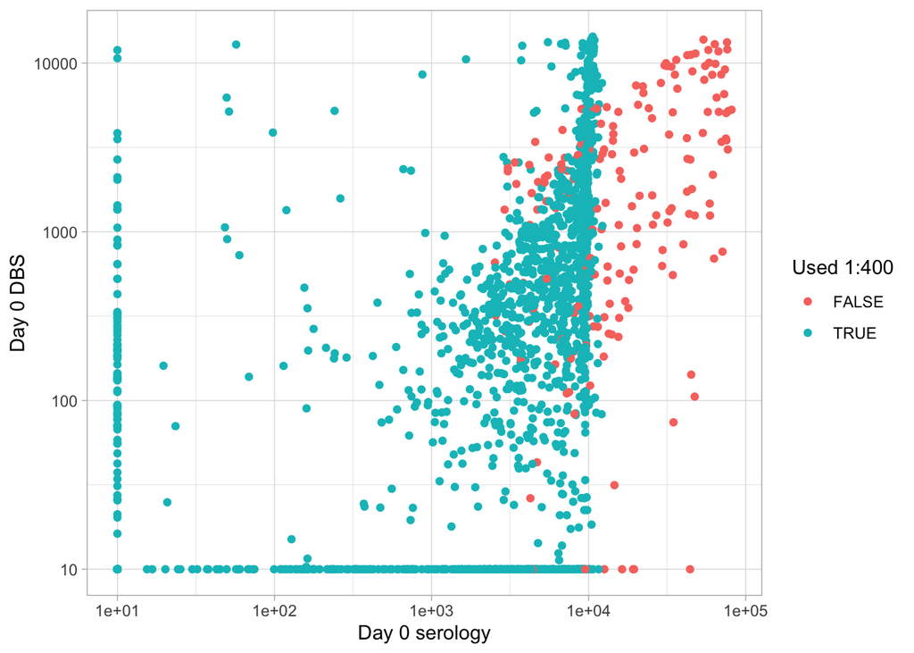

```r
df %>%
  filter(!is.na(coalesce(d0_1in400, d0_1in50)), !is.na(d0_dbs)) %>%
  ggplot(aes(x=coalesce(d0_1in400, d0_1in50), y=ifelse(d0_dbs<10,10,d0_dbs), color=is.na(d0_1in400))) +
  geom_point() +
  scale_x_continuous(name = "Day 0 serology", trans='log10') +
  scale_y_continuous(name = "Day 0 DBS", trans='log10') +
  scale_color_discrete(name="Used 1:400")
```

Plot of DBS vs serum at day 90

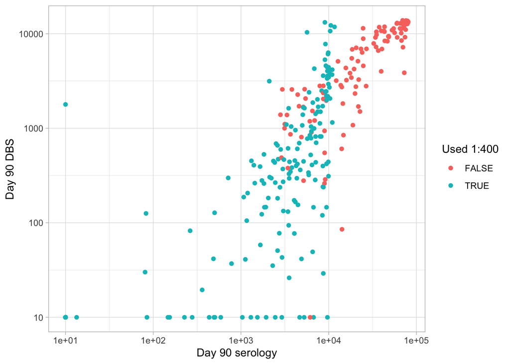

```r
df %>%
  filter(!is.na(coalesce(d90_1in400, d90_1in50)), !is.na(d90_dbs)) %>%
  ggplot(aes(x=coalesce(d90_1in400, d90_1in50), y=ifelse(d90_dbs<10,10,d90_dbs), color=is.na(d90_1in400))) +
  geom_point() +
  scale_x_continuous(name = "Day 90 serology", trans='log10') +
  scale_y_continuous(name = "Day 90 DBS", trans='log10') +
  scale_color_discrete(name="Used 1:400")
```

Use day 0 and day 90 data to work out conversion for DBS –> serum values. Remove very low values for both assays first and only use data above 7500 ng/ml on serum assay where this has come from the 1:400 assay (shown in red).

Prepare data

```r
plot_df =
  bind_rows(
      df %>%
        select(serum_1in50 = d90_1in50, serum_1in400 = d90_1in400, dbs = d90_dbs),
      df %>%
        select(serum_1in50 = d0_1in50, serum_1in400 = d0_1in400, dbs = d0_dbs)
  ) %>%
  filter(!is.na(coalesce(serum_1in400, serum_1in50)), !is.na(dbs)) %>% #remove missing data
  filter(!(serum_1in50>7500 & is.na(serum_1in400))) %>% # remove data points missing 1:400 data where should have it
  mutate(serum = coalesce(serum_1in400, serum_1in50)) %>%
  filter(serum>10, dbs>10)
```

Fit regression model comparing log10(dbs) to log10(serum). Here we save the DBS threshold calculated as the equivalent of 1250 ng/ml on the serum assay. This is used below.

```r
m = lm(log10(dbs) ~ log10(serum) + 0, data=plot_df)
summary(m)
```

```
##
## Call:
## lm(formula = log10(dbs) ~ log10(serum) + 0, data = plot_df)
##
## Residuals:
##      Min       1Q   Median       3Q      Max
## -1.76859 -0.32182  0.01472  0.38417  2.80965
##
## Coefficients:
##              Estimate Std. Error t value Pr(>|t|)
## log10(serum) 0.740271   0.004681   158.1   <2e-16 ***
## ---
## Signif. codes:  0 '***' 0.001 '**' 0.01 '*' 0.05 '.' 0.1 ' ' 1
##
## Residual standard error: 0.5505 on 987 degrees of freedom
## Multiple R-squared:  0.962,  Adjusted R-squared:  0.962
## F-statistic: 2.501e+04 on 1 and 987 DF,  p-value: < 2.2e-16
```

```r
(dbs_threshold = as.numeric(10^(predict(m, newdata=tibble(serum=1250)))))
```

```
## [1] 196.1338
```

Plot data - Dashed lines above indicate potential thresholds for each assay, determined using this linear model above

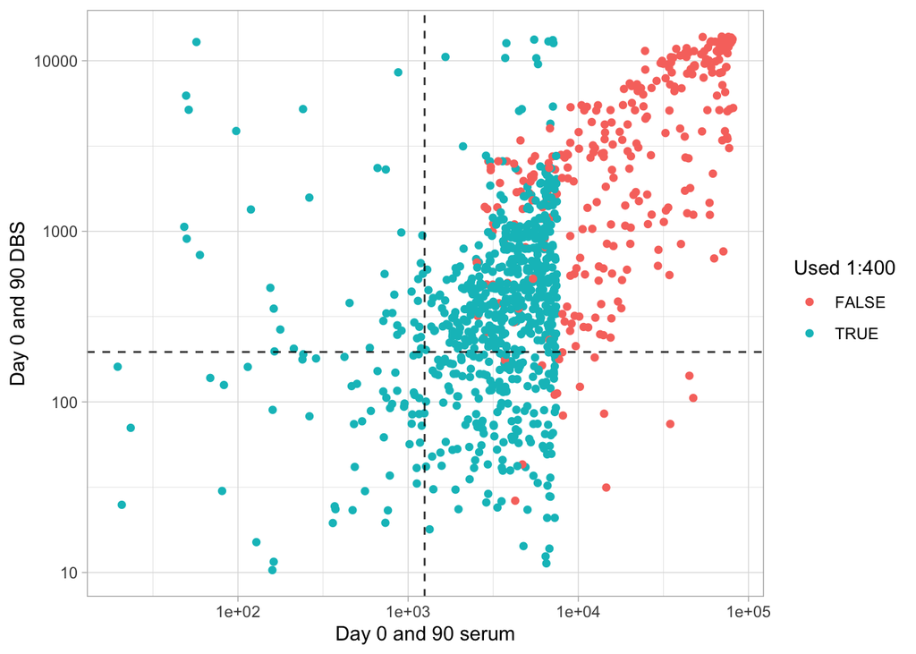

```r
plot_df %>%
  ggplot(aes(x=serum, y=dbs, color=is.na(serum_1in400))) +
  geom_point() +
  scale_x_continuous(name = "Day 0 and 90 serum", trans='log10') +
  scale_y_continuous(name = "Day 0 and 90 DBS", trans='log10') +
  scale_color_discrete(name="Used 1:400") +
  theme_light() +
  geom_vline(xintercept=1250, linetype="dashed", alpha=0.8) +
  geom_hline(yintercept=dbs_threshold, linetype="dashed", alpha=0.8)
```

# Further data preparation

## Summary variables for DBS

Record the first and last DBS values, assuming that DBS measurement stops after vaccination (no information provided to refute this)

```r
df = df %>%
  rowwise() %>%
  mutate(dbs_first = coalesce(d0_dbs, d30_dbs, d60_dbs),
         dbs_last = coalesce(vac_dbs, d90_dbs, d60_dbs, d30_dbs),
         dbs_first_label = case_when(
           !is.na(d0_dbs) ~ 'd0',
           !is.na(d30_dbs) ~ 'd30',
           !is.na(d60_dbs) ~ 'd60'
         ),
         dbs_last_label = case_when(
           !is.na(vac_dbs) ~ 'vaccine',
           !is.na(d90_dbs) ~ 'd90',
           !is.na(d60_dbs) ~ 'd60',
           !is.na(d30_dbs) ~ 'd30'
         ),
         dbs_available = case_when(
           dbs_first_label != dbs_last_label ~ 1,
           TRUE ~ 0
         )
  ) %>%
  mutate(dbs_ratio = dbs_last/dbs_first)
```

Summary of how many individuals have available DBS data

```r
df %>%
  filter(d0_1in50<=10) %>%
  count(dbs_available==1)
```

| dbs_available == 1 | n |
| --- | --- |
| FALSE | 625 |
| TRUE | 254 |

## Check 1:400 always have 1:50

Check for any 1:400 values without a corresponding 1:50 value

```r
df %>% filter(is.na(d0_1in50), !is.na(d0_1in400))
```

| subjectno | site | d0_1in50 | d90_1in50 | d0_1in400 | d90_1in400 | vac_1in50 | vac_1in400 | d0_dbs | d30_dbs | d60_dbs | d90_dbs | vac_dbs | pcr_result | pcr_date | randomisation_date | model | flag | dbs_first | dbs_last | dbs_first_label | dbs_last_label | dbs_available | dbs_ratio |
| --- | --- | --- | --- | --- | --- | --- | --- | --- | --- | --- | --- | --- | --- | --- | --- | --- | --- | --- | --- | --- | --- | --- | --- |

```r
df %>% filter(is.na(d90_1in50), !is.na(d90_1in400))
```

| subjectno | site | d0_1in50 | d90_1in50 | d0_1in400 | d90_1in400 | vac_1in50 | vac_1in400 | d0_dbs | d30_dbs | d60_dbs | d90_dbs | vac_dbs | pcr_result | pcr_date | randomisation_date | model | flag | dbs_first | dbs_last | dbs_first_label | dbs_last_label | dbs_available | dbs_ratio |
| --- | --- | --- | --- | --- | --- | --- | --- | --- | --- | --- | --- | --- | --- | --- | --- | --- | --- | --- | --- | --- | --- | --- | --- |

```r
df %>% filter(is.na(vac_1in50), !is.na(vac_1in400))
```

| subjectno | site | d0_1in50 | d90_1in50 | d0_1in400 | d90_1in400 | vac_1in50 | vac_1in400 | d0_dbs | d30_dbs | d60_dbs | d90_dbs | vac_dbs | pcr_result | pcr_date | randomisation_date | model | flag | dbs_first | dbs_last | dbs_first_label | dbs_last_label | dbs_available | dbs_ratio |
| --- | --- | --- | --- | --- | --- | --- | --- | --- | --- | --- | --- | --- | --- | --- | --- | --- | --- | --- | --- | --- | --- | --- | --- |

Safe to rely on 1:50 being present always when 1:400 present

Add summary column for if outcome based on vaccination

```r
df = df %>% mutate(
  vaccinated = ifelse(is.na(vac_1in50), 0, 1)
)

df %>% count(vaccinated)
```

| vaccinated | n |
| --- | --- |
| 0 | 4279 |
| 1 | 364 |

## Summary end value for serum

Check for any participants with vaccine and d90 end point

```r
df %>%
  filter(!is.na(d90_1in50), !is.na(vac_1in50))
```

| subjectno | site | d0_1in50 | d90_1in50 | d0_1in400 | d90_1in400 | vac_1in50 | vac_1in400 | d0_dbs | d30_dbs | d60_dbs | d90_dbs | vac_dbs | pcr_result | pcr_date | randomisation_date | model | flag | dbs_first | dbs_last | dbs_first_label | dbs_last_label | dbs_available | dbs_ratio | vaccinated |
| --- | --- | --- | --- | --- | --- | --- | --- | --- | --- | --- | --- | --- | --- | --- | --- | --- | --- | --- | --- | --- | --- | --- | --- | --- |
| E013-382 | Cote D'Ivoire | 2897.047 | 10010 | NA | 35461.19 | 5676.667 | NA | NA | NA | NA | NA | NA | NA |  | 2021-09-17 | 4 | NA | NA | NA | NA | NA | 0 | NA | 1 |
| A004-047 | Pakistan | 10.000 | 10 | NA | NA | 10.000 | NA | NA | NA | NA | NA | NA | NA |  | 2021-06-03 | NA | NA | NA | NA | NA | NA | 0 | NA | 1 |

For these two assume the correct end point is vaccination

```r
df = df %>%
  mutate(last_1in50 = coalesce(vac_1in50, d90_1in50),
      last_1in400 = ifelse(vaccinated == 0, d90_1in400, vac_1in400))
```

# Identify those who have serum data available

```r
df = df %>%
  mutate(
    serum_available = case_when(
      (d0_1in50 < 7500 | d0_1in400 >=2500) & (last_1in50 <7500 | last_1in400 >=2500) ~ 1, #valid results within limits set
      d0_1in50 < 1250 & last_1in50 >=1250 ~ 1, #seroconversion at 1:50 - so no 1:400 done
      d0_1in50 >= 1250 & last_1in50/d0_1in50 >=4 ~ 1, #4-fold rise at 1:50 - so no 1:400 done
      TRUE ~ 0
    )
  )
```

# Identify those with an outcome that can be assessed via serology

```r
df = df %>%
  mutate(outcome_possible = case_when(
    is.na(d0_1in50) & dbs_available == 0 ~ 'no: no serum or DBS at baseline',
    is.na(last_1in50) & dbs_available == 0 ~ 'no: no serum or DBS at follow up',
    d0_1in50 > 7500 & is.na(d0_1in400) & dbs_available == 0 ~ 'no: baseline 1:50 >7500 and no baseline 1:400',
    d0_1in50 >= 7500/4 & last_1in50 > 7500 & last_1in50/d0_1in50 <4
    & is.na(last_1in400) & dbs_available == 0 ~ 'no: f/u 1:50 >7500, no f/u 1:400, seeking 4-fold rise w/ 1:400',
    TRUE ~ 'yes: no exclusion met'
  ))

df %>%
  count(outcome_possible, serum_available, dbs_available)
```

| outcome_possible | serum_available | dbs_available | n |
| --- | --- | --- | --- |
| no: baseline 1:50 >7500 and no baseline 1:400 | 0 | 0 | 98 |
| no: f/u 1:50 >7500, no f/u 1:400, seeking 4-fold rise w/ 1:400 | 0 | 0 | 66 |
| no: no serum or DBS at baseline | 0 | 0 | 3 |
| no: no serum or DBS at follow up | 0 | 0 | 939 |
| yes: no exclusion met | 0 | 1 | 577 |
| yes: no exclusion met | 1 | 0 | 2332 |
| yes: no exclusion met | 1 | 1 | 628 |

# Record outcomes

Outcomes are recorded jointly whether vaccinated or not, but vaccination status held in separate column so can separate later.

```r
df = df %>%
  mutate(outcome = case_when(
    str_detect(outcome_possible, 'no:') ~ NA_character_, # if outcome not possible don't record one
    #binary sero-conversion
    serum_available==1 & d0_1in50 < 1250 & last_1in50 >=1250 & last_1in50/d0_1in50 >=4 ~ 'Binary seroconversion and 4-fold rise',
    serum_available==1 & d0_1in50 < 1250 & last_1in50 >=1250 & last_1in50/d0_1in50 <4 ~ 'Binary seroconversion and no 4-fold rise',
    # already sero-positive, 1in50 vs 1in50
    serum_available==1 & d0_1in50 >= 1250 & last_1in50/d0_1in50 >=4  ~ 'Baseline ab positive with 4-fold rise in 1:50',
    # already sero-positive, 1in400 vs 1in400
    serum_available==1 & d0_1in50 >= 1250 & last_1in400/d0_1in400 >=4  ~ 'Baseline ab positive with 4-fold rise in 1:400',
    # already sero-positive, 1in50 vs 1in400 later, with no 1:400 at baseline
    serum_available==1 & d0_1in50 >= 1250 & is.na(d0_1in400) & last_1in400/d0_1in50 >=4  ~ 'Baseline ab positive with 4-fold rise in 1:50 vs 1:400',
    # DBS seroconversion based on look-up value - only allow if serum not available
    serum_available==0 & dbs_first < dbs_threshold & dbs_last >= dbs_threshold & dbs_last/dbs_first >=4 ~ 'DBS binary seroconversion and 4-fold rise',
    serum_available==0 & dbs_first < dbs_threshold & dbs_last >= dbs_threshold & dbs_last/dbs_first <4 ~ 'DBS binary seroconversion and no 4-fold rise',
    # DBS 4-fold rise - only allow if serum not available
    serum_available==0 & dbs_first >= dbs_threshold & dbs_last/dbs_first >=4  ~ 'DBS baseline ab positive with 4-fold rise'
  ))

df %>%
  count(outcome_possible, outcome) %>%
  knitr::kable()
```

| outcome_possible | outcome | n |
| --- | --- | --- |
| no: baseline 1:50 >7500 and no baseline 1:400 | NA | 98 |
| no: f/u 1:50 >7500, no f/u 1:400, seeking 4-fold rise w/ 1:400 | NA | 66 |
| no: no serum or DBS at baseline | NA | 3 |
| no: no serum or DBS at follow up | NA | 939 |
| yes: no exclusion met | Baseline ab positive with 4-fold rise in 1:400 | 114 |
| yes: no exclusion met | Baseline ab positive with 4-fold rise in 1:50 | 99 |
| yes: no exclusion met | Baseline ab positive with 4-fold rise in 1:50 vs 1:400 | 274 |
| yes: no exclusion met | Binary seroconversion and 4-fold rise | 437 |
| yes: no exclusion met | Binary seroconversion and no 4-fold rise | 20 |
| yes: no exclusion met | DBS baseline ab positive with 4-fold rise | 42 |
| yes: no exclusion met | DBS binary seroconversion and 4-fold rise | 56 |
| yes: no exclusion met | DBS binary seroconversion and no 4-fold rise | 12 |
| yes: no exclusion met | NA | 2483 |

# Write output

```r
df$type_data = ifelse(df$serum_available==1, 'serum','DBS')
df$type_data[df$serum_available==0 & df$dbs_available==0]='None'
table(df$type_data, useNA = 'ifany')
```

```
##
##   DBS  None serum
##   577  1106  2960
```

```r
table(df$type_data, is.na(df$outcome))
```

```
##
##         FALSE TRUE
##   DBS     110  467
##   None      0 1106
##   serum   944 2016
```

```r
write_csv(df, 'Outputs/serology_outcomes.csv')
```

# Final check

Serum outcomes only with serum available, DBS outcomes only with DBS and no serum

```r
df %>% count(outcome_possible, outcome, serum_available, dbs_available) %>%
  knitr::kable()
```

| outcome_possible | outcome | serum_available | dbs_available | n |
| --- | --- | --- | --- | --- |
| no: baseline 1:50 >7500 and no baseline 1:400 | NA | 0 | 0 | 98 |
| no: f/u 1:50 >7500, no f/u 1:400, seeking 4-fold rise w/ 1:400 | NA | 0 | 0 | 66 |
| no: no serum or DBS at baseline | NA | 0 | 0 | 3 |
| no: no serum or DBS at follow up | NA | 0 | 0 | 939 |
| yes: no exclusion met | Baseline ab positive with 4-fold rise in 1:400 | 1 | 0 | 96 |
| yes: no exclusion met | Baseline ab positive with 4-fold rise in 1:400 | 1 | 1 | 18 |
| yes: no exclusion met | Baseline ab positive with 4-fold rise in 1:50 | 1 | 0 | 77 |
| yes: no exclusion met | Baseline ab positive with 4-fold rise in 1:50 | 1 | 1 | 22 |
| yes: no exclusion met | Baseline ab positive with 4-fold rise in 1:50 vs 1:400 | 1 | 0 | 211 |
| yes: no exclusion met | Baseline ab positive with 4-fold rise in 1:50 vs 1:400 | 1 | 1 | 63 |
| yes: no exclusion met | Binary seroconversion and 4-fold rise | 1 | 0 | 332 |
| yes: no exclusion met | Binary seroconversion and 4-fold rise | 1 | 1 | 105 |
| yes: no exclusion met | Binary seroconversion and no 4-fold rise | 1 | 0 | 17 |
| yes: no exclusion met | Binary seroconversion and no 4-fold rise | 1 | 1 | 3 |
| yes: no exclusion met | DBS baseline ab positive with 4-fold rise | 0 | 1 | 42 |
| yes: no exclusion met | DBS binary seroconversion and 4-fold rise | 0 | 1 | 56 |
| yes: no exclusion met | DBS binary seroconversion and no 4-fold rise | 0 | 1 | 12 |
| yes: no exclusion met | NA | 0 | 1 | 467 |
| yes: no exclusion met | NA | 1 | 0 | 1599 |
| yes: no exclusion met | NA | 1 | 1 | 417 |